# Votação Deputados

Mattheus Brito Rodrigues

06/10/2018

# Introdução

Esta análise será feita utilizando dados sobre as votações que candidatos à Câmara Federal de Deputados receberam nos anos de 2006 e 2010. Desse modo, será utilizado Regressão Linear para explicar essas votações. Logo abaixo será respondido 5 perguntas tomando como base os dados fornecidos

Antes de tudo, será importado as nossas bibliotecas que serão utilizadas para a plotagem das análises para responder as perguntas.

Logo após, será importado a nossa base de dados, sendo elas: eleicoes2006 (dados das eleições de 2006), eleicoes2010 (dados das eleições de 2010) e por fim eleicoes2006_2010 (dados das eleições de 2006 e 2010).

```r
eleicoes2006 <- read.csv("/Users/mattheusbrito/Downloads/AD2/Lab02/eleicoes_2006.csv")
eleicoes2010 <- read.csv("/Users/mattheusbrito/Downloads/AD2/Lab02/eleicoes_2010.csv")
eleicoes2006_2010 <- read.csv("/Users/mattheusbrito/Downloads/AD2/Lab02/eleicoes_2006_e_2010.csv")
```

Antes de partir para as perguntas, é necessário entender o que cada coluna da nossa base de dados significa:

- “sequencial_candidato” :(character) id do candidato
- “nome”: (character)
- “uf”: (character)
- “partido”: (character)
- “quantidade_doacoes”: (integer)
- “quantidade_doadores”: (integer) número de doadores diferentes
- “total_receita”: (double) soma em R$ das doações
- “media_receita”: (double) média das doações
- “recursos_de_outros_candidatos/comites”: (double) quantia em R$ das doações provenientes de outros candidatos ou comite partidário
- “recursos_de_pessoas_fisicas”: (double) quantia em R$ das doações provenientes de outros CPFs
- “recursos_de_pessoas_juridicas”: (double) quantia em R$ das doações provenientes de outros CNPJ
- “recursos_proprios”: (double) quantia em R$ das doações provenientes do próprio candidato
- “recursos_de_partido_politico”: (double) quantia em R$ das doações provenientes do partido político do candidato
- “votos”: (integer) variável alvo. Se refere ao número de votos na campanha de 2006 e 2010
- “quantidade_despesas”: (integer)
- “quantidade_fornecedores”: (integer) número de fornecedores/despesas diferentes
- “total_despesa”: (double) soma em R$ das despesas de campanha
- “media_despesa”: (double) média das despesas de campanha
- “cargo”: (character)
- “Sexo”: (character)
- “grau”: (character) grau de instrução do candidato
- “estado_civil”: (character)
- “ocupacao”: (character) ocupação do candidato

Após entender as variáveis disponíveis, será feito uma verificação se há ausência de dados nas tabelas: * 2006

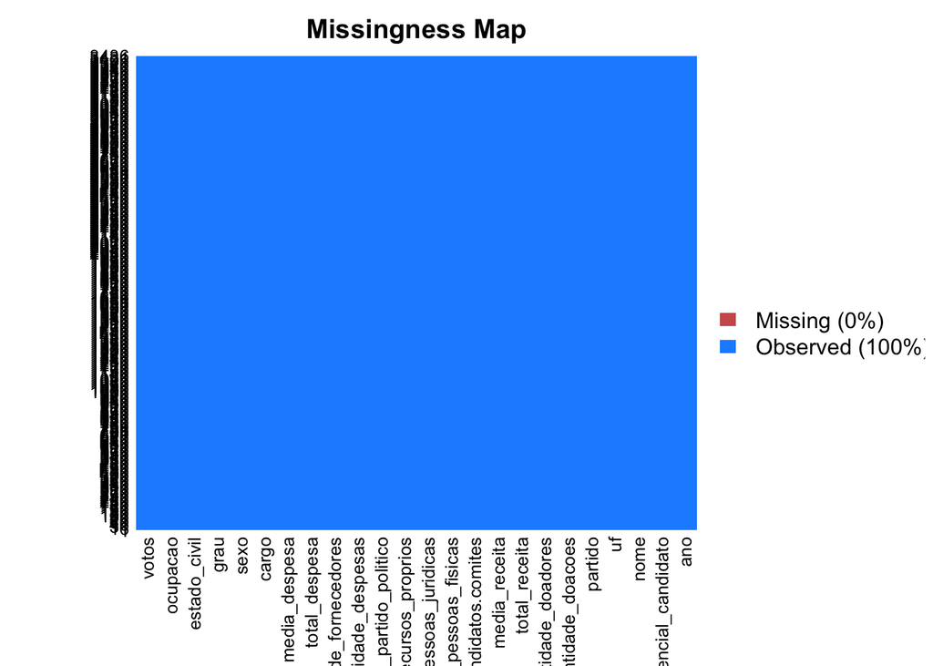

```r
missmap(eleicoes2006)
```

- 2010

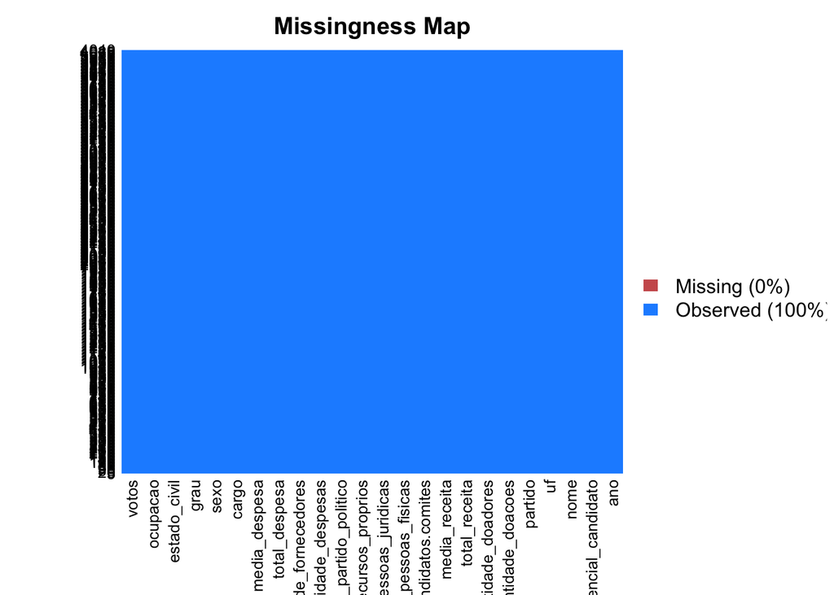

```r
missmap(eleicoes2010)
```

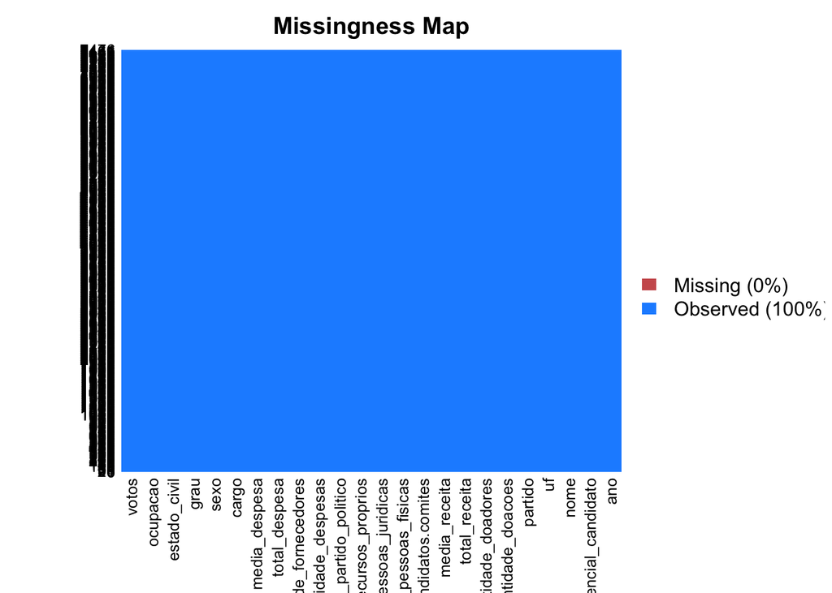

```r
missmap(eleicoes2006_2010)
```

Através dos três gráficos acima, pode-se confirmar que não há nenhum dado faltando nas três tabelas. Sendo assim, podemos seguir em frente com a nossa análise.

# Perguntas

#### 1 - Um modelo de regressão múltipla com todas as variáveis é plausível para explicar a variação em y (número de votos) em 2006? Mesma pergunta para 2010.

- 2006 Não, pois algumas variáveis que estão nos dados evidentemente não possuem relação como o número de votos e também são categoricas. Por esse motivo as seguintes variáveis foram removidas:
- cargo
- sequencial_candidato
- nome

```r
eleicoes2006_rm <- eleicoes2006 %>%
   select(-c(cargo, sequencial_candidato, nome))
```

Mesmo assim, ainda podem existir variáveis que não são boas preditoras, mas que não foram retiradas. Desse modo, gerou-se um modelo para verificar isso tornando possível observar a importância de cada variável no modelo resultante

```r
modelo2006 <- lm(votos~., data = eleicoes2006_rm)
```

```r
glance(modelo2006)
```

```
## # A tibble: 1 x 11
##   r.squared adj.r.squared  sigma statistic p.value    df  logLik    AIC
## *     <dbl>         <dbl>  <dbl>     <dbl>   <dbl> <int>   <dbl>  <dbl>
## 1     0.578         0.549 30545.      19.9       0   222 -40244. 80934.
## # ... with 3 more variables: BIC <dbl>, deviance <dbl>, df.residual <int>
```

No momento, é interessante que se atente à variável “r.squared” que tem o valor de 0.5778645.

```r
anova(modelo2006)
```

```
## Analysis of Variance Table
##
## Response: votos
##                                         Df     Sum Sq    Mean Sq   F value
## uf                                      26 1.9846e+11 7.6329e+09    8.1813
## partido                                 28 7.8920e+11 2.8186e+10   30.2104
## quantidade_doacoes                       1 1.1279e+12 1.1279e+12 1208.9146
## quantidade_doadores                      1 1.7282e+10 1.7282e+10   18.5231
## total_receita                            1 1.2684e+12 1.2684e+12 1359.5283
## media_receita                            1 1.4433e+11 1.4433e+11  154.6970
## recursos_de_outros_candidatos.comites    1 3.2991e+09 3.2991e+09    3.5361
## recursos_de_pessoas_fisicas              1 3.4729e+10 3.4729e+10   37.2238
## recursos_de_pessoas_juridicas            1 8.8225e+10 8.8225e+10   94.5625
## recursos_proprios                        1 4.2737e+09 4.2737e+09    4.5807
## quantidade_despesas                      1 5.8131e+10 5.8131e+10   62.3073
## quantidade_fornecedores                  1 2.5174e+09 2.5174e+09    2.6983
## total_despesa                            1 1.0411e+11 1.0411e+11  111.5870
## media_despesa                            1 2.0730e+09 2.0730e+09    2.2219
## sexo                                     1 2.0785e+09 2.0785e+09    2.2278
## grau                                     6 7.2530e+09 1.2088e+09    1.2957
## estado_civil                             4 1.2601e+09 3.1502e+08    0.3377
## ocupacao                               144 2.5130e+11 1.7451e+09    1.8705
## Residuals                             3214 2.9986e+12 9.3298e+08
##                                          Pr(>F)
## uf                                    < 2.2e-16 ***
## partido                               < 2.2e-16 ***
## quantidade_doacoes                    < 2.2e-16 ***
## quantidade_doadores                   1.729e-05 ***
## total_receita                         < 2.2e-16 ***
## media_receita                         < 2.2e-16 ***
## recursos_de_outros_candidatos.comites   0.06014 .
## recursos_de_pessoas_fisicas           1.179e-09 ***
## recursos_de_pessoas_juridicas         < 2.2e-16 ***
## recursos_proprios                       0.03241 *
## quantidade_despesas                   3.997e-15 ***
## quantidade_fornecedores                 0.10055
## total_despesa                         < 2.2e-16 ***
## media_despesa                           0.13616
## sexo                                    0.13565
## grau                                    0.25548
## estado_civil                            0.85271
## ocupacao                              3.983e-09 ***
## Residuals
## ---
## Signif. codes:  0 '***' 0.001 '**' 0.01 '*' 0.05 '.' 0.1 ' ' 1
```

Após analisar a tabela acima, pode-se notar que algumas variáveis tem p-valor > 0.05, dessa forma, não tem muita significância para o nosso modelo de dados, são elas: * recursos_de_outros_candidatos * quantidade_fornecedores * media_despesa * sexo * grau * estado_civil

Sendo assim, é possível afirmar que um modelo de regressão linear com todas as variáveis não é plausível para explicar a variação do número de votos em 2006.

- 2010 Não, pois algumas variáveis que estão nos dados evidentemente não possuem relação como o número de votos e também são categoricas. Por esse motivo as seguintes variáveis foram removidas:
- cargo
- sequencial_candidato
- nome

```r
eleicoes2010_rm <- eleicoes2010 %>%
   select(-c(cargo, sequencial_candidato, nome))
```

Mesmo assim, ainda podem existir variáveis que não são boas preditoras, mas que não foram retiradas. Desse modo, gerou-se um modelo para verificar isso tornando possível observar a importância de cada variável no modelo resultante

```r
modelo2010 <- lm(votos~., data = eleicoes2010_rm)
```

```r
glance(modelo2010)
```

```
## # A tibble: 1 x 11
##   r.squared adj.r.squared  sigma statistic p.value    df  logLik    AIC
## *     <dbl>         <dbl>  <dbl>     <dbl>   <dbl> <int>   <dbl>  <dbl>
## 1     0.541         0.513 34587.      19.6       0   230 -47837. 96136.
## # ... with 3 more variables: BIC <dbl>, deviance <dbl>, df.residual <int>
```

No momento, é interessante que se atente à variável “r.squared” que tem o valor de 0.5405282.

```r
anova(modelo2010)
```

```
## Analysis of Variance Table
##
## Response: votos
##                                         Df     Sum Sq    Mean Sq   F value
## uf                                      26 2.2711e+11 8.7349e+09    7.3017
## partido                                 26 1.0530e+12 4.0500e+10   33.8552
## quantidade_doacoes                       1 4.9125e+11 4.9125e+11  410.6436
## quantidade_doadores                      1 3.1724e+10 3.1724e+10   26.5189
## total_receita                            1 2.5149e+12 2.5149e+12 2102.2577
## media_receita                            1 1.2681e+10 1.2681e+10   10.6007
## recursos_de_outros_candidatos.comites    1 4.6985e+10 4.6985e+10   39.2755
## recursos_de_pessoas_fisicas              1 5.8902e+10 5.8902e+10   49.2372
## recursos_de_pessoas_juridicas            1 2.7507e+10 2.7507e+10   22.9939
## recursos_proprios                        1 4.8877e+10 4.8877e+10   40.8572
## recursos_de_partido_politico             1 7.7882e+06 7.7882e+06    0.0065
## quantidade_despesas                      1 3.1002e+10 3.1002e+10   25.9152
## quantidade_fornecedores                  1 3.5029e+09 3.5029e+09    2.9282
## total_despesa                            1 8.3297e+10 8.3297e+10   69.6301
## media_despesa                            1 4.8708e+09 4.8708e+09    4.0716
## sexo                                     1 3.9112e+09 3.9112e+09    3.2695
## grau                                     6 6.8017e+10 1.1336e+10    9.4761
## estado_civil                             4 1.1412e+10 2.8530e+09    2.3849
## ocupacao                               153 6.4294e+11 4.2022e+09    3.5127
## Residuals                             3810 4.5578e+12 1.1963e+09
##                                          Pr(>F)
## uf                                    < 2.2e-16 ***
## partido                               < 2.2e-16 ***
## quantidade_doacoes                    < 2.2e-16 ***
## quantidade_doadores                   2.742e-07 ***
## total_receita                         < 2.2e-16 ***
## media_receita                           0.00114 **
## recursos_de_outros_candidatos.comites 4.090e-10 ***
## recursos_de_pessoas_fisicas           2.673e-12 ***
## recursos_de_pessoas_juridicas         1.687e-06 ***
## recursos_proprios                     1.836e-10 ***
## recursos_de_partido_politico            0.93570
## quantidade_despesas                   3.740e-07 ***
## quantidade_fornecedores                 0.08713 .
## total_despesa                         < 2.2e-16 ***
## media_despesa                           0.04368 *
## sexo                                    0.07066 .
## grau                                  2.343e-10 ***
## estado_civil                            0.04913 *
## ocupacao                              < 2.2e-16 ***
## Residuals
## ---
## Signif. codes:  0 '***' 0.001 '**' 0.01 '*' 0.05 '.' 0.1 ' ' 1
```

Após analisar a tabela acima, pode-se notar que algumas variáveis tem p-valor > 0.05, dessa forma, não tem muita significância para o nosso modelo de dados, são elas: * recursos_de_partido_politico * quantidade_fornecedores * sexo

Sendo assim, é possível afirmar que um modelo de regressão linear com todas as variáveis não é plausível para explicar a variação do número de votos em 2010.

#### 2 - Compare as regressões construídas para 2006 e 2010. Quais as diferenças/semelhanças percebidas? Algumas sugestões:

#### 2.1 - Analise os plots de resíduos e verifique se há tendências nos erros para cada ano.

- 2006

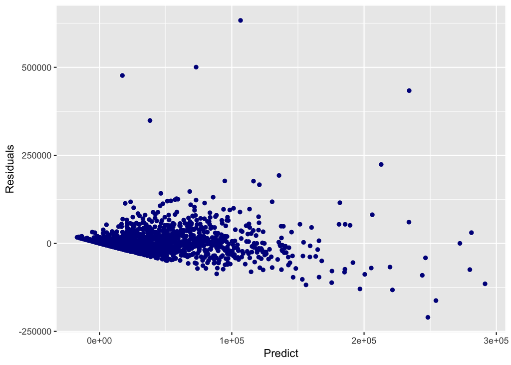

```r
ggplot(modelo2006, aes(x = predict(modelo2006), y = residuals(modelo2006))) +
  geom_point(color= "darkblue") +
  xlab("Predict") +
  ylab("Residuals")
```

Após a plotagem do gráfico, percebemos que os resíduos são assimétrico e que por mais que tenha alguns pontos distantes, ainda há uma aglomeração que significa um padrão de comportamento, ou seja, não são aleatórios. Isso significa que o modelo não é ideal e que faltam transformações ou interações entre as variáveis.

- 2010

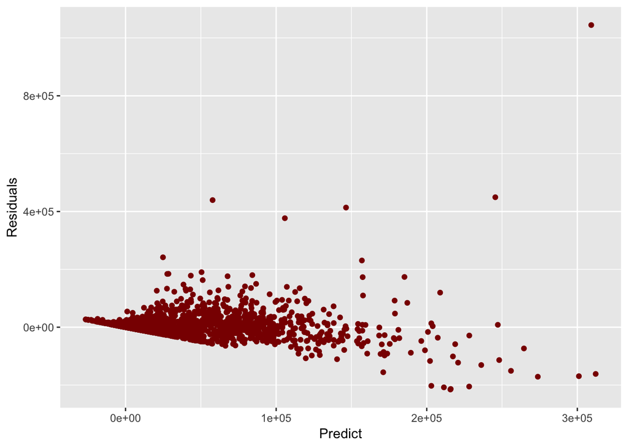

```r
ggplot(modelo2010, aes(x = predict(modelo2010), y = residuals(modelo2010))) +
  geom_point(color= "darkred") +
  xlab("Predict") +
  ylab("Residuals")
```

Após a plotagem do gráfico, percebemos que os resíduos são assimétrico e que por mais que tenha alguns pontos distantes, ainda há uma aglomeração que significa um padrão de comportamento, ou seja, não são aleatórios. Isso significa que o modelo não é ideal e que faltam transformações ou interações entre as variáveis.

#### 2.2 - Quais variáveis conseguem explicar melhor o número de votos? Compare essas variáveis entre os modelos. Mesma coisa para as variáveis menos explicativas.

Para responder a pergunta utilizaremos os valores de R² para comparar os modelos.

- 2006

```r
eleicoes2006_melhor <- eleicoes2006_rm %>%
  select(-uf)

modeloMelhorado2006 <- lm(votos~., data = eleicoes2006_melhor)

glance(modeloMelhorado2006)
```

```
## # A tibble: 1 x 11
##   r.squared adj.r.squared  sigma statistic p.value    df  logLik    AIC
## *     <dbl>         <dbl>  <dbl>     <dbl>   <dbl> <int>   <dbl>  <dbl>
## 1     0.564         0.538 30914.      21.5       0   196 -40299. 80992.
## # ... with 3 more variables: BIC <dbl>, deviance <dbl>, df.residual <int>
```

No modelo acima foi retirado a variável “uf” que tem bastante significância para o modelo.

```r
eleicoes2006_pior <- eleicoes2006_rm %>%
  select(-sexo)

modeloPiorado2006 <- lm(votos~., data = eleicoes2006_pior)

glance(modeloPiorado2006)
```

```
## # A tibble: 1 x 11
##   r.squared adj.r.squared  sigma statistic p.value    df  logLik    AIC
## *     <dbl>         <dbl>  <dbl>     <dbl>   <dbl> <int>   <dbl>  <dbl>
## 1     0.578         0.549 30540.      20.0       0   221 -40244. 80932.
## # ... with 3 more variables: BIC <dbl>, deviance <dbl>, df.residual <int>
```

No modelo acima foi retirado a variável “sexo” que tem pouca significância para o modelo.

```r
glance(modelo2006)
```

```
## # A tibble: 1 x 11
##   r.squared adj.r.squared  sigma statistic p.value    df  logLik    AIC
## *     <dbl>         <dbl>  <dbl>     <dbl>   <dbl> <int>   <dbl>  <dbl>
## 1     0.578         0.549 30545.      19.9       0   222 -40244. 80934.
## # ... with 3 more variables: BIC <dbl>, deviance <dbl>, df.residual <int>
```

```r
diferenca1 = glance(modelo2006)$adj.r.squared - glance(modeloMelhorado2006)$adj.r.squared
diferenca2 = glance(modelo2006)$adj.r.squared - glance(modeloPiorado2006)$adj.r.squared
```

Observamos que a diferença do valor do R² ajustado é de 0.011 entre o primeiro modelo e o modelo original, já a diferença entre o segundo modelo e o original é de 0, logo podemos dizer que quando retira a variável “uf” temos mudanças mais significantes, do que quando retira-se a variável “sexo”.

- 2010

```r
eleicoes2010_melhor <- eleicoes2010_rm %>%
  select(-partido)

modeloMelhorado2010 <- lm(votos~., data = eleicoes2010_melhor)

glance(modeloMelhorado2010)
```

```
## # A tibble: 1 x 11
##   r.squared adj.r.squared  sigma statistic p.value    df  logLik    AIC
## *     <dbl>         <dbl>  <dbl>     <dbl>   <dbl> <int>   <dbl>  <dbl>
## 1     0.532         0.507 34792.      21.5       0   204 -47875. 96159.
## # ... with 3 more variables: BIC <dbl>, deviance <dbl>, df.residual <int>
```

No modelo acima foi retirado a variável “partido” que tem bastante significância para o modelo.

```r
eleicoes2010_pior <- eleicoes2010_rm %>%
  select(-quantidade_fornecedores)

modeloPiorado2010 <- lm(votos~., data = eleicoes2010_pior)

glance(modeloPiorado2010)
```

```
## # A tibble: 1 x 11
##   r.squared adj.r.squared  sigma statistic p.value    df  logLik    AIC
## *     <dbl>         <dbl>  <dbl>     <dbl>   <dbl> <int>   <dbl>  <dbl>
## 1     0.540         0.512 34607.      19.6       0   229 -47840. 96140.
## # ... with 3 more variables: BIC <dbl>, deviance <dbl>, df.residual <int>
```

No modelo acima foi retirado a variável “quantidade_fornecedores” que tem pouca significância para o modelo.

```r
glance(modelo2010)
```

```
## # A tibble: 1 x 11
##   r.squared adj.r.squared  sigma statistic p.value    df  logLik    AIC
## *     <dbl>         <dbl>  <dbl>     <dbl>   <dbl> <int>   <dbl>  <dbl>
## 1     0.541         0.513 34587.      19.6       0   230 -47837. 96136.
## # ... with 3 more variables: BIC <dbl>, deviance <dbl>, df.residual <int>
```

```r
diferenca3 = glance(modelo2010)$adj.r.squared - glance(modeloMelhorado2010)$adj.r.squared
diferenca4 = glance(modelo2010)$adj.r.squared - glance(modeloPiorado2010)$adj.r.squared
```

Observamos que a diferença do valor do R² ajustado é de 0.006 entre o primeiro modelo e o modelo original, já a diferença entre o segundo modelo e o original é de 0.001, logo podemos dizer que quando retira a variável “partido” temos mudanças mais significantes, do que quando retira-se a variável “quantidade_fornecedores”.

#### 3 - Todas as variáveis são úteis para os modelos de regressão? Há variáveis redudantes? Faça análises para 2006 e 2010 separadamente.

- 2006

```r
eleicoes2006_cor <- eleicoes2006_rm %>%
  select(-c(quantidade_doadores, estado_civil, ano))
```

Para responder a pergunta, é preciso observar a correlação entre as variáveis.

No entanto temos algumas variáveis do tipo factor, neste caso vamos convertê-las para inteiro para que seja possível calcular correlação dela com as demais variáveis.

```r
dadosCorrelacao2006 <- eleicoes2006_cor %>%
  mutate(uf = as.numeric(uf)) %>%
  mutate(partido = as.numeric(partido)) %>%
  mutate(sexo = as.numeric(sexo)) %>%
  mutate(grau = as.numeric(grau)) %>%
  mutate(ocupacao = as.numeric(ocupacao))
  round(2)
```

```
## [1] 2
```

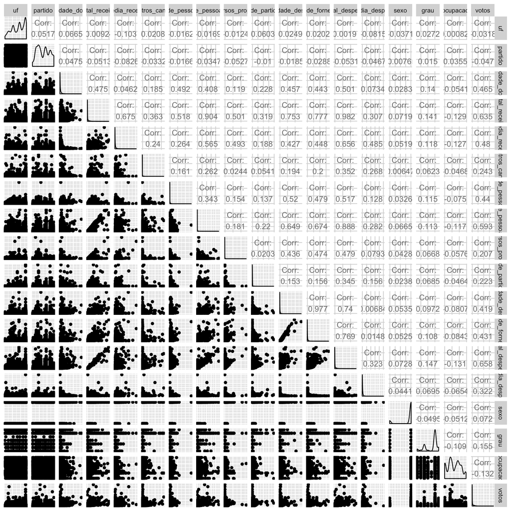

```r
ggpairs(dadosCorrelacao2006, axisLabels = "none")
```

Observamos uma alta correlação entre “total_despesa” e “total_receita” (0,982) e também entre “total_despesa” e “recursos_de_pessoas_juridicas” (0,888), por isso iremos remover a variável “total_despesa”.

- 2010

```r
eleicoes2010_cor <- eleicoes2010_rm %>%
  select(-c(quantidade_doadores, estado_civil, ano))
```

Para responder a pergunta, é preciso observar a correlação entre as variáveis.

No entanto temos algumas variáveis do tipo factor, neste caso vamos convertê-las para inteiro para que seja possível calcular correlação dela com as demais variáveis.

```r
dadosCorrelacao2010 <- eleicoes2010_cor %>%
  mutate(uf = as.numeric(uf)) %>%
  mutate(partido = as.numeric(partido)) %>%
  mutate(sexo = as.numeric(sexo)) %>%
  mutate(grau = as.numeric(grau)) %>%
  mutate(ocupacao = as.numeric(ocupacao))
  round(2)
```

```
## [1] 2
```

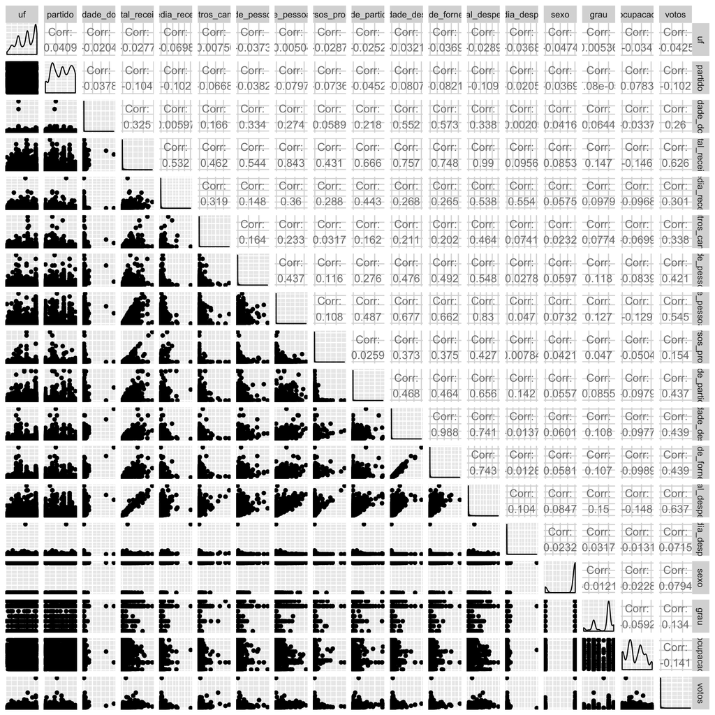

```r
ggpairs(dadosCorrelacao2010, axisLabels = "none")
```

Observamos uma alta correlação entre “total_despesa” e “total_receita” (0,99) e também entre “total_despesa” e “recursos_de_pessoas_juridicas” (0,83), por isso iremos remover a variável “total_despesa”.

```r
eleicoesRS2 <- eleicoes2006_rm %>%
  select(-total_despesa)

modeloRS2 <- lm(votos~., data = eleicoesRS2)

glance(modeloRS2)
```

```
## # A tibble: 1 x 11
##   r.squared adj.r.squared  sigma statistic p.value    df  logLik    AIC
## *     <dbl>         <dbl>  <dbl>     <dbl>   <dbl> <int>   <dbl>  <dbl>
## 1     0.565         0.535 31012.      19.0       0   221 -40297. 81038.
## # ... with 3 more variables: BIC <dbl>, deviance <dbl>, df.residual <int>
```

```r
glance(modelo2006)
```

```
## # A tibble: 1 x 11
##   r.squared adj.r.squared  sigma statistic p.value    df  logLik    AIC
## *     <dbl>         <dbl>  <dbl>     <dbl>   <dbl> <int>   <dbl>  <dbl>
## 1     0.578         0.549 30545.      19.9       0   222 -40244. 80934.
## # ... with 3 more variables: BIC <dbl>, deviance <dbl>, df.residual <int>
```

```r
diferenca = glance(modelo2006)$adj.r.squared - glance(modeloRS2)$adj.r.squared

round(diferenca,3)
```

```
## [1] 0.014
```

Acredito que, considerando que a taxa de aumento de erro e de diminuição do R² ajustado foi baixa (0.014), então a retirada da variável total_despesa não acarretou em mudanças muito drásticas no modelo.

#### 5 - Construa agora uma regressão considerando os anos 2006 e 2010 em conjunto. Que diferenças/semelhanças você percebe em relação aos modelos individuais por ano? Veja a questão 2 para sugestões que você usar para comparação.

```r
eleicoes <- eleicoes2006_2010  %>% select(-c(nome, sequencial_candidato, cargo, ano, ocupacao, uf))

modelo_novo <- lm(data = eleicoes, votos ~., na.action = na.omit)

modelo_novo %>%   summary()
```

```
##
## Call:
## lm(formula = votos ~ ., data = eleicoes, na.action = na.omit)
##
## Residuals:
##     Min      1Q  Median      3Q     Max
## -325910  -11474   -4532    1880 1261518
##
## Coefficients: (1 not defined because of singularities)
##                                         Estimate Std. Error t value
## (Intercept)                            5.298e+02  3.546e+03   0.149
## partidoPAN                            -4.051e+03  5.562e+03  -0.728
## partidoPC do B                         6.227e+03  4.029e+03   1.545
## partidoPCB                            -8.095e+03  1.004e+04  -0.806
## partidoPCO                            -5.023e+03  1.234e+04  -0.407
## partidoPDT                             8.718e+02  3.270e+03   0.267
## partidoPFL                             2.058e+04  3.893e+03   5.285
## partidoPHS                            -4.315e+03  3.747e+03  -1.152
## partidoPL                              7.604e+03  4.027e+03   1.888
## partidoPMDB                            1.055e+04  3.201e+03   3.297
## partidoPMN                            -2.993e+03  3.611e+03  -0.829
## partidoPP                              1.186e+04  3.463e+03   3.425
## partidoPPS                             2.934e+02  3.472e+03   0.085
## partidoPR                              1.876e+04  4.184e+03   4.485
## partidoPRB                             3.305e+03  4.341e+03   0.762
## partidoPRONA                           2.197e+03  5.004e+03   0.439
## partidoPRP                            -4.307e+03  4.496e+03  -0.958
## partidoPRTB                           -5.897e+03  4.291e+03  -1.374
## partidoPSB                             7.579e+03  3.275e+03   2.314
## partidoPSC                             1.563e+03  3.580e+03   0.437
## partidoPSDB                            6.522e+03  3.265e+03   1.997
## partidoPSDC                           -5.275e+03  4.448e+03  -1.186
## partidoPSL                            -6.287e+03  4.058e+03  -1.550
## partidoPSOL                           -2.255e+03  3.544e+03  -0.636
## partidoPSTU                           -4.180e+03  6.317e+03  -0.662
## partidoPT                              9.809e+03  3.197e+03   3.068
## partidoPT do B                        -2.887e+03  4.252e+03  -0.679
## partidoPTB                             1.281e+03  3.354e+03   0.382
## partidoPTC                            -2.905e+03  3.656e+03  -0.795
## partidoPTN                            -6.275e+03  4.707e+03  -1.333
```

[output cut: 72 more lines]

```
## grauENSINO MÉDIO COMPLETO             0.359328
## grauENSINO MÉDIO INCOMPLETO           0.717577
## grauLÊ E ESCREVE                      6.87e-11 ***
## grauSUPERIOR COMPLETO                 0.000465 ***
## grauSUPERIOR INCOMPLETO               0.179589
## estado_civilDIVORCIADO(A)             0.048528 *
## estado_civilSEPARADO(A) JUDICIALMENTE 0.399172
## estado_civilSOLTEIRO(A)               0.003866 **
## estado_civilVIÚVO(A)                  0.141455
## ---
## Signif. codes:  0 '***' 0.001 '**' 0.01 '*' 0.05 '.' 0.1 ' ' 1
##
## Residual standard error: 35930 on 7422 degrees of freedom
## Multiple R-squared:  0.4373, Adjusted R-squared:  0.4333
## F-statistic: 108.8 on 53 and 7422 DF,  p-value: < 2.2e-16
```